# CA2 - Genetic & Game

**Ali Borzoozadeh - 810102410**

### 📊 Matplotlib – Data Visualization in Python

matplotlib is a python library that is mainly used for data visualization. This library allows you to plot different type of figures including scatters and histograms. In the first part of this project you are supposed to implement a genetic algorithm. To visualize plots that are required in the project description use plotting as much as you can because it gives a great insight on what is happening during each run. It also helps you to compare your results whenevever you want to understand effect of different parameters during different runs. For more information, check [this notebook](https://github.com/jakevdp/PythonDataScienceHandbook/blob/master/notebooks/04.00-Introduction-To-Matplotlib.ipynb) and visit [the website](https://matplotlib.org/stable/tutorials/pyplot.html#sphx-glr-tutorials-pyplot-py).

```python
import matplotlib.pyplot as plt
```

# Genetic Algorithm

```python
import random
import itertools
import numpy as np
```

```python
# algorithm parameters
numCoeffs = 41
populationSize = 100
generations = 100
mutationRate = 0.15
functionRange = (-np.pi, np.pi)
sampleCount = 100
```

```python
# These functions are given as samples to use in the algorithm
def getTargetFunction(functionName="sin_cos"):
    def sinCosFunction(t):
        """Target function: sin(2πt) + 0.5*cos(4πt)."""
        return np.sin(2 * np.pi * t) + 0.5 * np.cos(4 * np.pi * t)

    def linearFunction(t):
        """Simple linear function: y = 2t + 1."""
        return 2 * t + 1

    def quadraticFunction(t):
        """Quadratic function: y = 4t^2 - 4t + 2."""
        return 4 * (t**2) - 4 * t + 2

    def cubicFunction(t):
        """Cubic function: y = 8t^3 - 12t^2 + 6t."""
        return 8 * (t**3) - 12 * (t**2) + 6 * t

    def gaussianFunction(t):
        """Gaussian function centered at t=0.5."""
        mu = 0.5
        sigma = 0.1  # Adjust sigma to control the width of the peak
        return np.exp(-((t - mu) ** 2) / (2 * sigma**2))

    def squareWaveFunction(t):
        """Approximation of a square wave. Smoothed for better Fourier approximation."""
        return 0.5 * (np.sign(np.sin(2 * np.pi * t)) + 1)

    def sawtoothFunction(t):
        """Sawtooth wave, normalized to [0, 1]."""
        return (t * 5) % 1

    def complexFourierFunction(t):
        return (
            np.sin(2 * np.pi * t)
            + 0.3 * np.cos(4 * np.pi * t)
            + 0.2 * np.sin(6 * np.pi * t)
            + 0.1 * np.cos(8 * np.pi * t)
        )

    def polynomialFunction(t):
        return 10 * (t**5) - 20 * (t**4) + 15 * (t**3) - 4 * (t**2) + t + 0.5

    functionOptions = {
        "sin_cos": sinCosFunction,
        "linear": linearFunction,
        "quadratic": quadraticFunction,
        "cubic": cubicFunction,
        "gaussian": gaussianFunction,
        "square_wave": squareWaveFunction,
        "sawtooth": sawtoothFunction,
        "complex_fourier": complexFourierFunction,
        "polynomial": polynomialFunction,
    }

    selectedFunction = functionOptions.get(functionName.lower())
    if selectedFunction:
        return selectedFunction
```

```python
# generate samples
tSamples = np.linspace(functionRange[0], functionRange[1], sampleCount)
fSamples = getTargetFunction()(tSamples)
```

⚠️ Important Note:

Using **NumPy arrays** allows you to perform operations on vectors **more efficiently** and **faster**.

**Avoid using `for` loops** whenever possible, as vectorized operations in NumPy are **optimized for performance** and significantly reduce execution time.

```
Running Genetic Algorithm for sin_cos Function:

Using Tournament Selection and Single_point Crossover:
Generation 1: Best Fitness = -2.094122
Generation 2: Best Fitness = -2.007098
Generation 3: Best Fitness = -2.007098
Generation 4: Best Fitness = -1.965451
Generation 5: Best Fitness = -1.679890
Generation 6: Best Fitness = -1.650440
Generation 7: Best Fitness = -1.650440
Generation 8: Best Fitness = -1.650440
Generation 9: Best Fitness = -1.629875
Generation 10: Best Fitness = -1.609008
Generation 11: Best Fitness = -1.472097
Generation 12: Best Fitness = -1.472097
Generation 13: Best Fitness = -1.472097
Generation 14: Best Fitness = -1.417410
Generation 15: Best Fitness = -1.417410
Generation 16: Best Fitness = -1.417273
Generation 17: Best Fitness = -1.367517
Generation 18: Best Fitness = -1.242471
Generation 19: Best Fitness = -1.242471
Generation 20: Best Fitness = -1.204814
Generation 21: Best Fitness = -1.204814
Generation 22: Best Fitness = -1.204814
Generation 23: Best Fitness = -1.144791
Generation 24: Best Fitness = -1.069677
Generation 25: Best Fitness = -1.061813
Generation 26: Best Fitness = -1.035824
Generation 27: Best Fitness = -1.010484
Generation 28: Best Fitness = -0.942626
Generation 29: Best Fitness = -0.923722
Generation 30: Best Fitness = -0.923722
Generation 31: Best Fitness = -0.804196
Generation 32: Best Fitness = -0.804196
Generation 33: Best Fitness = -0.804196
Generation 34: Best Fitness = -0.804196
Generation 35: Best Fitness = -0.804196
Generation 36: Best Fitness = -0.772705
Generation 37: Best Fitness = -0.772705
```

[output cut: 48 more lines]

```
Generation 86: Best Fitness = -0.360359
Generation 87: Best Fitness = -0.360359
Generation 88: Best Fitness = -0.343355
Generation 89: Best Fitness = -0.343355
Generation 90: Best Fitness = -0.343355
Generation 91: Best Fitness = -0.343355
Generation 92: Best Fitness = -0.343355
Generation 93: Best Fitness = -0.343355
Generation 94: Best Fitness = -0.343355
Generation 95: Best Fitness = -0.343355
Generation 96: Best Fitness = -0.343355
Generation 97: Best Fitness = -0.343355
Generation 98: Best Fitness = -0.343355
Generation 99: Best Fitness = -0.343355
Generation 100: Best Fitness = -0.343355
```

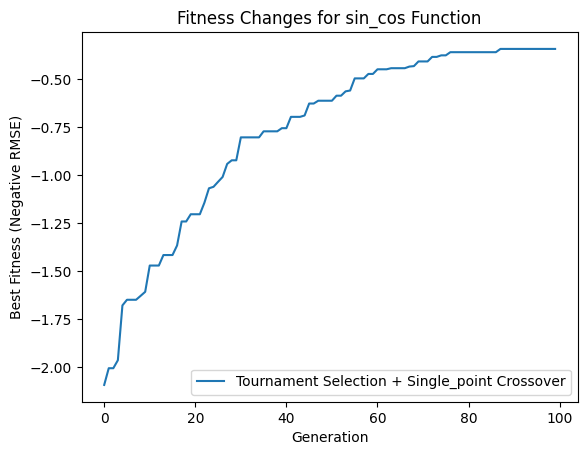

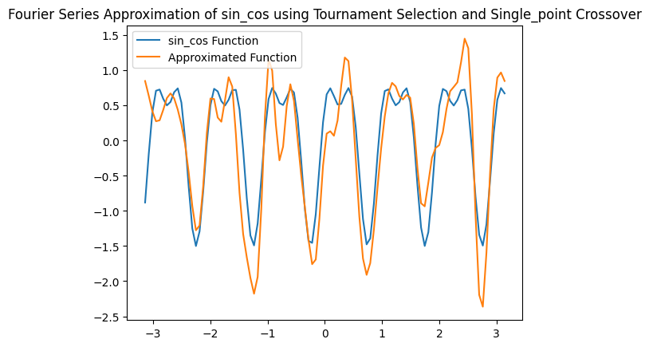

```
Using Tournament Selection and Two_point Crossover:
Generation 1: Best Fitness = -2.265083
Generation 2: Best Fitness = -2.127296
Generation 3: Best Fitness = -2.127296
Generation 4: Best Fitness = -2.093337
Generation 5: Best Fitness = -1.984130
Generation 6: Best Fitness = -1.911379
Generation 7: Best Fitness = -1.884140
Generation 8: Best Fitness = -1.830765
Generation 9: Best Fitness = -1.772898
Generation 10: Best Fitness = -1.713825
Generation 11: Best Fitness = -1.696506
Generation 12: Best Fitness = -1.648166
Generation 13: Best Fitness = -1.603483
Generation 14: Best Fitness = -1.483783
Generation 15: Best Fitness = -1.459664
Generation 16: Best Fitness = -1.442590
Generation 17: Best Fitness = -1.364542
Generation 18: Best Fitness = -1.349926
Generation 19: Best Fitness = -1.293429
Generation 20: Best Fitness = -1.212394
Generation 21: Best Fitness = -1.187826
Generation 22: Best Fitness = -1.174891
Generation 23: Best Fitness = -1.113864
Generation 24: Best Fitness = -1.113864
Generation 25: Best Fitness = -1.057776
Generation 26: Best Fitness = -1.041062
Generation 27: Best Fitness = -1.041062
Generation 28: Best Fitness = -1.020542
Generation 29: Best Fitness = -1.020424
Generation 30: Best Fitness = -0.925499
Generation 31: Best Fitness = -0.920069
Generation 32: Best Fitness = -0.874276
Generation 33: Best Fitness = -0.874276
Generation 34: Best Fitness = -0.841229
Generation 35: Best Fitness = -0.841229
Generation 36: Best Fitness = -0.841229
Generation 37: Best Fitness = -0.829326
Generation 38: Best Fitness = -0.781530
Generation 39: Best Fitness = -0.780050
```

[output cut: 46 more lines]

```
Generation 86: Best Fitness = -0.390869
Generation 87: Best Fitness = -0.390869
Generation 88: Best Fitness = -0.390869
Generation 89: Best Fitness = -0.390869
Generation 90: Best Fitness = -0.390869
Generation 91: Best Fitness = -0.390869
Generation 92: Best Fitness = -0.385672
Generation 93: Best Fitness = -0.385672
Generation 94: Best Fitness = -0.385672
Generation 95: Best Fitness = -0.385672
Generation 96: Best Fitness = -0.385672
Generation 97: Best Fitness = -0.385672
Generation 98: Best Fitness = -0.385672
Generation 99: Best Fitness = -0.385672
Generation 100: Best Fitness = -0.385672
```

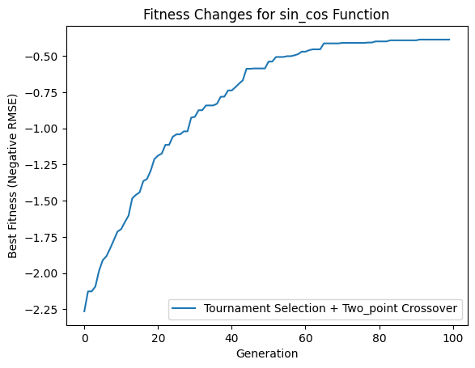

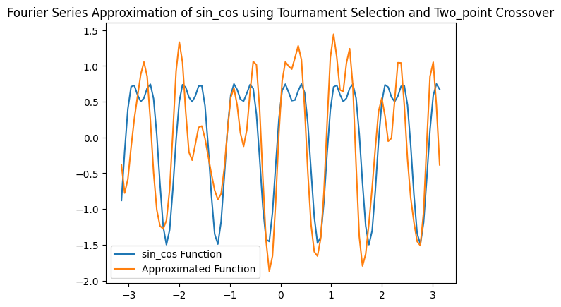

```
Using Tournament Selection and Uniform Crossover:
Generation 1: Best Fitness = -1.979523
Generation 2: Best Fitness = -1.979523
Generation 3: Best Fitness = -1.979523
Generation 4: Best Fitness = -1.979523
Generation 5: Best Fitness = -1.897817
Generation 6: Best Fitness = -1.811842
Generation 7: Best Fitness = -1.662412
Generation 8: Best Fitness = -1.662412
Generation 9: Best Fitness = -1.600806
Generation 10: Best Fitness = -1.493641
Generation 11: Best Fitness = -1.331441
Generation 12: Best Fitness = -1.266616
Generation 13: Best Fitness = -1.266616
Generation 14: Best Fitness = -1.255309
Generation 15: Best Fitness = -1.183788
Generation 16: Best Fitness = -1.127307
Generation 17: Best Fitness = -1.111734
Generation 18: Best Fitness = -1.046682
Generation 19: Best Fitness = -1.014507
Generation 20: Best Fitness = -0.894319
Generation 21: Best Fitness = -0.889448
Generation 22: Best Fitness = -0.864835
Generation 23: Best Fitness = -0.725916
Generation 24: Best Fitness = -0.725916
Generation 25: Best Fitness = -0.725916
Generation 26: Best Fitness = -0.725916
Generation 27: Best Fitness = -0.725916
Generation 28: Best Fitness = -0.692568
Generation 29: Best Fitness = -0.692568
Generation 30: Best Fitness = -0.667850
Generation 31: Best Fitness = -0.667850
Generation 32: Best Fitness = -0.666418
Generation 33: Best Fitness = -0.635556
Generation 34: Best Fitness = -0.635556
Generation 35: Best Fitness = -0.603309
Generation 36: Best Fitness = -0.603309
Generation 37: Best Fitness = -0.603309
Generation 38: Best Fitness = -0.603309
Generation 39: Best Fitness = -0.568963
```

[output cut: 46 more lines]

```
Generation 86: Best Fitness = -0.326870
Generation 87: Best Fitness = -0.326870
Generation 88: Best Fitness = -0.326870
Generation 89: Best Fitness = -0.326870
Generation 90: Best Fitness = -0.326870
Generation 91: Best Fitness = -0.326870
Generation 92: Best Fitness = -0.326870
Generation 93: Best Fitness = -0.326870
Generation 94: Best Fitness = -0.326870
Generation 95: Best Fitness = -0.326870
Generation 96: Best Fitness = -0.326870
Generation 97: Best Fitness = -0.326870
Generation 98: Best Fitness = -0.326870
Generation 99: Best Fitness = -0.326870
Generation 100: Best Fitness = -0.326870
```

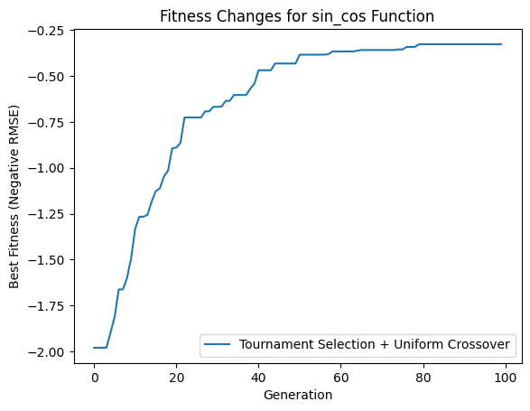

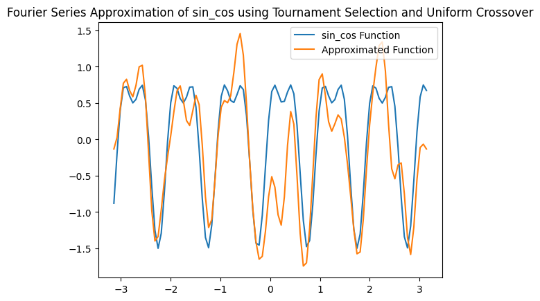

```
Using Roulette Selection and Single_point Crossover:
Generation 1: Best Fitness = -2.162589
Generation 2: Best Fitness = -2.028314
Generation 3: Best Fitness = -1.937256
Generation 4: Best Fitness = -1.933549
Generation 5: Best Fitness = -1.933549
Generation 6: Best Fitness = -1.933549
Generation 7: Best Fitness = -1.876316
Generation 8: Best Fitness = -1.832288
Generation 9: Best Fitness = -1.760046
Generation 10: Best Fitness = -1.760046
Generation 11: Best Fitness = -1.760046
Generation 12: Best Fitness = -1.723238
Generation 13: Best Fitness = -1.703744
Generation 14: Best Fitness = -1.680786
Generation 15: Best Fitness = -1.594824
Generation 16: Best Fitness = -1.594824
Generation 17: Best Fitness = -1.557259
Generation 18: Best Fitness = -1.518775
Generation 19: Best Fitness = -1.516087
Generation 20: Best Fitness = -1.450860
Generation 21: Best Fitness = -1.450860
Generation 22: Best Fitness = -1.399501
Generation 23: Best Fitness = -1.370827
Generation 24: Best Fitness = -1.352265
Generation 25: Best Fitness = -1.302333
Generation 26: Best Fitness = -1.254843
Generation 27: Best Fitness = -1.254843
Generation 28: Best Fitness = -1.254843
Generation 29: Best Fitness = -1.210434
Generation 30: Best Fitness = -1.187665
Generation 31: Best Fitness = -1.152938
Generation 32: Best Fitness = -1.123024
Generation 33: Best Fitness = -1.123024
Generation 34: Best Fitness = -1.074863
Generation 35: Best Fitness = -1.044987
Generation 36: Best Fitness = -1.043876
Generation 37: Best Fitness = -1.043876
Generation 38: Best Fitness = -0.993828
Generation 39: Best Fitness = -0.993828
```

[output cut: 46 more lines]

```
Generation 86: Best Fitness = -0.513986
Generation 87: Best Fitness = -0.513986
Generation 88: Best Fitness = -0.513986
Generation 89: Best Fitness = -0.494295
Generation 90: Best Fitness = -0.494295
Generation 91: Best Fitness = -0.494295
Generation 92: Best Fitness = -0.494295
Generation 93: Best Fitness = -0.492354
Generation 94: Best Fitness = -0.492354
Generation 95: Best Fitness = -0.492354
Generation 96: Best Fitness = -0.492354
Generation 97: Best Fitness = -0.471674
Generation 98: Best Fitness = -0.467336
Generation 99: Best Fitness = -0.467336
Generation 100: Best Fitness = -0.467336
```

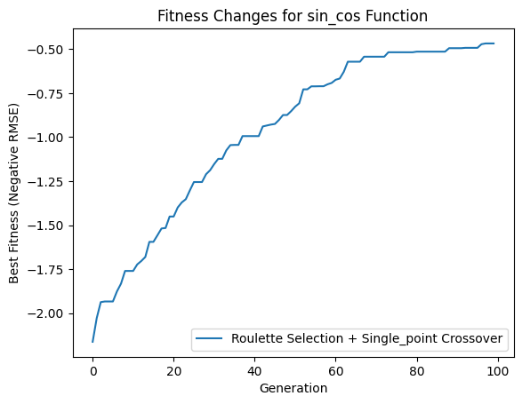

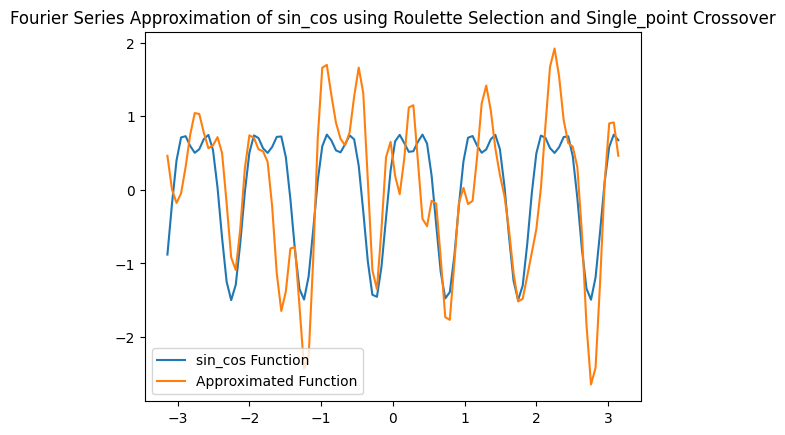

```
Using Roulette Selection and Two_point Crossover:
Generation 1: Best Fitness = -2.108392
Generation 2: Best Fitness = -2.022611
Generation 3: Best Fitness = -2.018019
Generation 4: Best Fitness = -1.901760
Generation 5: Best Fitness = -1.788229
Generation 6: Best Fitness = -1.692993
Generation 7: Best Fitness = -1.677050
Generation 8: Best Fitness = -1.557149
Generation 9: Best Fitness = -1.528982
Generation 10: Best Fitness = -1.345081
Generation 11: Best Fitness = -1.341238
Generation 12: Best Fitness = -1.306224
Generation 13: Best Fitness = -1.270272
Generation 14: Best Fitness = -1.163483
Generation 15: Best Fitness = -1.115745
Generation 16: Best Fitness = -1.115745
Generation 17: Best Fitness = -1.115745
Generation 18: Best Fitness = -1.115745
Generation 19: Best Fitness = -1.115745
Generation 20: Best Fitness = -1.065038
Generation 21: Best Fitness = -1.065038
Generation 22: Best Fitness = -1.038631
Generation 23: Best Fitness = -1.038631
Generation 24: Best Fitness = -0.985573
Generation 25: Best Fitness = -0.985573
Generation 26: Best Fitness = -0.985573
Generation 27: Best Fitness = -0.977971
Generation 28: Best Fitness = -0.911183
Generation 29: Best Fitness = -0.911183
Generation 30: Best Fitness = -0.911183
Generation 31: Best Fitness = -0.851761
Generation 32: Best Fitness = -0.851761
Generation 33: Best Fitness = -0.838627
Generation 34: Best Fitness = -0.778160
Generation 35: Best Fitness = -0.751267
Generation 36: Best Fitness = -0.751267
Generation 37: Best Fitness = -0.749525
Generation 38: Best Fitness = -0.749525
Generation 39: Best Fitness = -0.654566
```

[output cut: 46 more lines]

```
Generation 86: Best Fitness = -0.420688
Generation 87: Best Fitness = -0.420688
Generation 88: Best Fitness = -0.405437
Generation 89: Best Fitness = -0.405437
Generation 90: Best Fitness = -0.405437
Generation 91: Best Fitness = -0.405437
Generation 92: Best Fitness = -0.405437
Generation 93: Best Fitness = -0.405437
Generation 94: Best Fitness = -0.405437
Generation 95: Best Fitness = -0.405437
Generation 96: Best Fitness = -0.405437
Generation 97: Best Fitness = -0.405437
Generation 98: Best Fitness = -0.405437
Generation 99: Best Fitness = -0.405437
Generation 100: Best Fitness = -0.377366
```

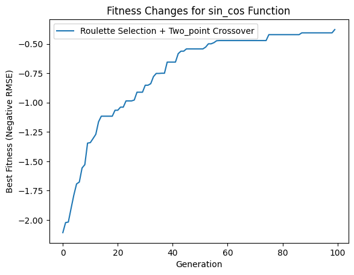

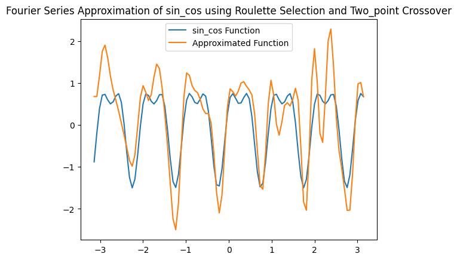

```
Using Roulette Selection and Uniform Crossover:
Generation 1: Best Fitness = -2.143155
Generation 2: Best Fitness = -2.131180
Generation 3: Best Fitness = -1.912401
Generation 4: Best Fitness = -1.912401
Generation 5: Best Fitness = -1.912401
Generation 6: Best Fitness = -1.912401
Generation 7: Best Fitness = -1.818585
Generation 8: Best Fitness = -1.765196
Generation 9: Best Fitness = -1.765196
Generation 10: Best Fitness = -1.723656
Generation 11: Best Fitness = -1.716254
Generation 12: Best Fitness = -1.645097
Generation 13: Best Fitness = -1.628147
Generation 14: Best Fitness = -1.449868
Generation 15: Best Fitness = -1.400552
Generation 16: Best Fitness = -1.397911
Generation 17: Best Fitness = -1.297439
Generation 18: Best Fitness = -1.297439
Generation 19: Best Fitness = -1.254123
Generation 20: Best Fitness = -1.254123
Generation 21: Best Fitness = -1.217992
Generation 22: Best Fitness = -1.152014
Generation 23: Best Fitness = -1.152014
Generation 24: Best Fitness = -1.077329
Generation 25: Best Fitness = -1.052396
Generation 26: Best Fitness = -1.052396
Generation 27: Best Fitness = -1.042872
Generation 28: Best Fitness = -1.024368
Generation 29: Best Fitness = -0.969642
Generation 30: Best Fitness = -0.969642
Generation 31: Best Fitness = -0.923946
Generation 32: Best Fitness = -0.878075
Generation 33: Best Fitness = -0.854007
Generation 34: Best Fitness = -0.843904
Generation 35: Best Fitness = -0.843904
Generation 36: Best Fitness = -0.813051
Generation 37: Best Fitness = -0.811031
Generation 38: Best Fitness = -0.810108
Generation 39: Best Fitness = -0.761048
```

[output cut: 46 more lines]

```
Generation 86: Best Fitness = -0.416498
Generation 87: Best Fitness = -0.416498
Generation 88: Best Fitness = -0.416498
Generation 89: Best Fitness = -0.413686
Generation 90: Best Fitness = -0.413686
Generation 91: Best Fitness = -0.413686
Generation 92: Best Fitness = -0.413686
Generation 93: Best Fitness = -0.413686
Generation 94: Best Fitness = -0.413686
Generation 95: Best Fitness = -0.413686
Generation 96: Best Fitness = -0.413686
Generation 97: Best Fitness = -0.413686
Generation 98: Best Fitness = -0.413686
Generation 99: Best Fitness = -0.413686
Generation 100: Best Fitness = -0.413686
```

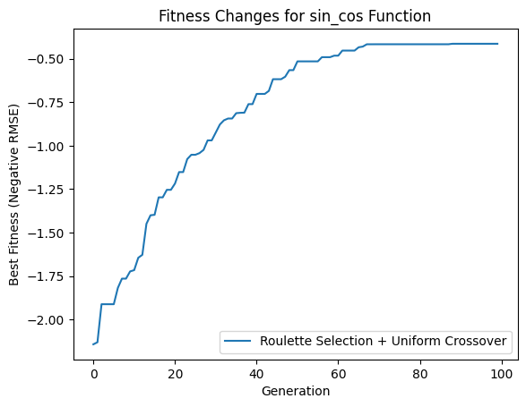

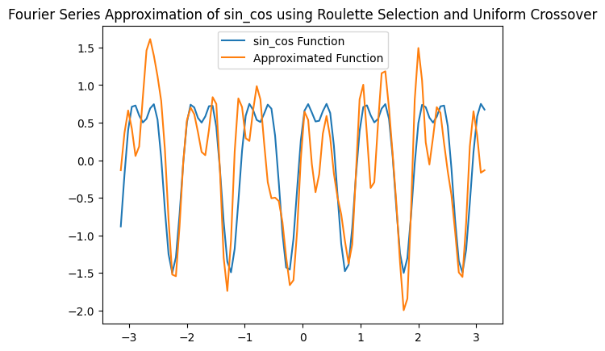

```
Using Rank Selection and Single_point Crossover:
Generation 1: Best Fitness = -2.322382
Generation 2: Best Fitness = -2.192075
Generation 3: Best Fitness = -2.148258
Generation 4: Best Fitness = -2.044137
Generation 5: Best Fitness = -2.044137
Generation 6: Best Fitness = -1.977657
Generation 7: Best Fitness = -1.971217
Generation 8: Best Fitness = -1.865437
Generation 9: Best Fitness = -1.844772
Generation 10: Best Fitness = -1.803453
Generation 11: Best Fitness = -1.702240
Generation 12: Best Fitness = -1.467832
Generation 13: Best Fitness = -1.467832
Generation 14: Best Fitness = -1.467832
Generation 15: Best Fitness = -1.444364
Generation 16: Best Fitness = -1.432463
Generation 17: Best Fitness = -1.389547
Generation 18: Best Fitness = -1.331507
Generation 19: Best Fitness = -1.300236
Generation 20: Best Fitness = -1.159582
Generation 21: Best Fitness = -1.159582
Generation 22: Best Fitness = -1.086933
Generation 23: Best Fitness = -1.015507
Generation 24: Best Fitness = -1.015507
Generation 25: Best Fitness = -1.015507
Generation 26: Best Fitness = -1.015507
Generation 27: Best Fitness = -0.996984
Generation 28: Best Fitness = -0.954751
Generation 29: Best Fitness = -0.954751
Generation 30: Best Fitness = -0.832672
Generation 31: Best Fitness = -0.828175
Generation 32: Best Fitness = -0.828175
Generation 33: Best Fitness = -0.780062
Generation 34: Best Fitness = -0.780062
Generation 35: Best Fitness = -0.761430
Generation 36: Best Fitness = -0.757487
Generation 37: Best Fitness = -0.730108
Generation 38: Best Fitness = -0.672703
Generation 39: Best Fitness = -0.671016
```

[output cut: 46 more lines]

```
Generation 86: Best Fitness = -0.392492
Generation 87: Best Fitness = -0.392492
Generation 88: Best Fitness = -0.392492
Generation 89: Best Fitness = -0.392492
Generation 90: Best Fitness = -0.392492
Generation 91: Best Fitness = -0.392492
Generation 92: Best Fitness = -0.392492
Generation 93: Best Fitness = -0.392492
Generation 94: Best Fitness = -0.392492
Generation 95: Best Fitness = -0.392492
Generation 96: Best Fitness = -0.392492
Generation 97: Best Fitness = -0.392492
Generation 98: Best Fitness = -0.392492
Generation 99: Best Fitness = -0.392492
Generation 100: Best Fitness = -0.392492
```

[22 more figures not shown]

```python
def fourier_series(t, coeffs):
    a0 = coeffs[0]
    series = a0 / 2
    for n in range(1, 21):
        series += coeffs[n] * np.cos(n * t) + coeffs[20 + n] * np.sin(n * t)
    return series

# Using RMSE as the fitness function
def fitness(coeffs):
    predicted = fourier_series(tSamples, coeffs)
    rmse = np.sqrt(np.mean((fSamples - predicted) ** 2))
    return -rmse  # Negative because we want to maximize fitness

def initialize_population():
    return [np.random.uniform(-1, 1, numCoeffs) for _ in range(populationSize)]

def roulette_wheel_selection(population, fitnesses):
    min_fitness = min(fitnesses)
    offset = abs(min_fitness) + 1e-6
    adjusted_fitnesses = [f + offset for f in fitnesses]

    total_fitness = sum(adjusted_fitnesses)
    probabilities = [f / total_fitness for f in adjusted_fitnesses]

    selected_index = random.choices(range(len(population)), weights=probabilities, k=1)[0]
    return population[selected_index]

def rank_selection(population, fitnesses):
    sorted_indices = np.argsort(fitnesses)
    ranks = np.arange(1, len(fitnesses) + 1)
    probabilities = ranks / ranks.sum()
    sorted_population = [population[i] for i in sorted_indices]
    return random.choices(sorted_population, weights=probabilities, k=1)[0]

def tournament_selection(population, fitnesses):
    idx1, idx2 = random.sample(range(len(population)), 2)
    return population[idx1] if fitnesses[idx1] > fitnesses[idx2] else population[idx2]

def single_point_crossover(parent1, parent2):
    point = random.randint(1, len(parent1) - 1)
    child1 = np.concatenate((parent1[:point], parent2[point:]))
    child2 = np.concatenate((parent2[:point], parent1[point:]))

    return child1, child2

def two_point_crossover(parent1, parent2):
    point1, point2 = sorted(random.sample(range(1, len(parent1)), 2))
    child1 = np.concatenate((parent1[:point1], parent2[point1:point2], parent1[point2:]))
    child2 = np.concatenate((parent2[:point1], parent1[point1:point2], parent2[point2:]))

    return child1, child2

def uniform_crossover(parent1, parent2):
    mask = np.random.randint(0, 2, size=numCoeffs)
    child1 = np.where(mask == 1, parent1, parent2)
    child2 = np.where(mask == 1, parent2, parent1)

    return child1, child2

def mutate(individual):
    for i in range(numCoeffs):
        if random.random() < mutationRate:
            individual[i] += np.random.normal(0, 0.1)
    return individual

def genetic_algorithm(selection_method="roulette", crossover_method="uniform"):
    selection_function = selection_methods.get(selection_method)
    crossover_function = crossover_methods.get(crossover_method)
    population = initialize_population()
    best_solution = None
    best_fitness = float('-inf')
    fitness_history = []

    for generation in range(generations):
        fitnesses = [fitness(ind) for ind in population]
        new_population = []

        for _ in range(populationSize // 2):
            parent1 = selection_function(population, fitnesses)
            parent2 = selection_function(population, fitnesses)
            child1, child2 = crossover_function(parent1, parent2)
            new_population.append(mutate(child1))
            new_population.append(mutate(child2))

        population = new_population

        max_fitness_idx = np.argmax(fitnesses)
        if fitnesses[max_fitness_idx] > best_fitness:
            best_fitness = fitnesses[max_fitness_idx]
            best_solution = population[max_fitness_idx]

        print(f"Generation {generation + 1}: Best Fitness = {best_fitness:.6f}")
        fitness_history.append(best_fitness)

    return best_solution, fitness_history

functions = ["linear", "quadratic", "cubic", "gaussian", "square_wave", "sawtooth", "complex_fourier", "polynomial"]

selection_methods = {
    "tournament": tournament_selection,
    "roulette": roulette_wheel_selection,
    "rank": rank_selection
}

crossover_methods = {
    "single_point": single_point_crossover,
    "two_point": two_point_crossover,
    "uniform": uniform_crossover
}

print(f"\nRunning Genetic Algorithm for sin_cos Function:")
fSamples = getTargetFunction("sin_cos")(tSamples)
for selection in selection_methods:
    for crossover in crossover_methods:
        print(f"\nUsing {selection.capitalize()} Selection and {crossover.capitalize()} Crossover:")
        best_coeffs, fitness_history = genetic_algorithm(selection, crossover)

        plt.plot(fitness_history, label=f"{selection.capitalize()} Selection + {crossover.capitalize()} Crossover")
        plt.xlabel("Generation")
        plt.ylabel("Best Fitness (Negative RMSE)")
        plt.title("Fitness Changes for sin_cos Function")
        plt.legend()
        plt.show()

        plt.plot(tSamples, fSamples, label="sin_cos Function")
        plt.plot(tSamples, fourier_series(tSamples, best_coeffs), label="Approximated Function")
        plt.legend()
        plt.title(f"Fourier Series Approximation of sin_cos using {selection.capitalize()} Selection and {crossover.capitalize()} Crossover")
        plt.show()

for function_name in functions:
    print(f"\nRunning Genetic Algorithm for {function_name} Function:")
    fSamples = getTargetFunction(function_name)(tSamples)

    selection = "rank"
    crossover = "uniform"

    print(f"\nUsing {selection.capitalize()} Selection and {crossover.capitalize()} Crossover:")
    best_coeffs, fitness_history = genetic_algorithm(selection, crossover)

    plt.plot(fitness_history, label=f"{selection.capitalize()} Selection + {crossover.capitalize()} Crossover")
    plt.xlabel("Generation")
    plt.ylabel("Best Fitness (Negative RMSE)")
    plt.title(f"Fitness Changes for {function_name} Function")
    plt.legend()
    plt.show()

    plt.plot(tSamples, fSamples, label=f"{function_name} Function")
    plt.plot(tSamples, fourier_series(tSamples, best_coeffs), label="Approximated Function")
    plt.legend()
    plt.title(f"Fourier Series Approximation of {function_name} using {selection.capitalize()} Selection and {crossover.capitalize()} Crossover")
    plt.show()
```

## Questions

### Question 1:

Considering that the initial value of each coefficient is between -1 and 1 with eight decimal places, the number of possible states for a coefficient becomes:

$(1 - (-1)) \times 10^8 = 2 \times 10^8 = 200{,}000{,}000$

Since there are 41 coefficients, the total state space is:

$(200{,}000{,}000)^{41}$

$\log_{10}(\text{State space}) = 41 \times \log_{10}(200{,}000{,}000) \\\approx 41 \times 8.30103 \\\approx 340.342$

$\text{State space} \approx 10^{340.342}$

The state space is astronomically large, approximately $10^{340}$. This demonstrates the infeasibility of brute force approaches and the necessity of optimization techniques like genetic algorithms to explore this vast search space efficiently.

### Question 2:

Ideas that can help the genetic algorithm converge faster:

#### 1. **Elitism**:

- **Explanation**: Elitism ensures that the best individuals from the current generation are carried over to the next generation without modification. This prevents the loss of high-quality solutions due to random mutations or crossover.
- **Implementation**: At the end of each generation, we will identify the top `k` individuals (e.g., the top 5% of the population) based on fitness and directly we'll copy them into the next generation. The remaining population can be filled using the usual genetic operations (selection, crossover, and mutation).
- **Benefit**: By preserving the best solutions, the algorithm avoids "forgetting" good solutions and ensures steady progress toward convergence.

#### 2. **Adaptive Mutation Rate**:

- **Explanation**: Instead of using a fixed mutation rate, we can adapt the mutation rate dynamically based on the diversity of the population or the progress of the algorithm. For example:
  - We use a **higher mutation rate** in the early generations to explore the search space more broadly.
  - Gradually we reduce the mutation rate in later generations to fine-tune the solutions.
- **Implementation**: The mutation rate can be adjusted based on the generation number or the fitness improvement rate. For instance:

  ```
  mutationRate = initialRate * (1 - (currentGeneration / totalGenerations))
  ```

- **Benefit**: This approach balances exploration and exploitation, allowing the algorithm to explore diverse solutions early on and focus on refining the best solutions later.

### Question 3:

Two common strategies for selecting the next generation:

#### 1. **Roulette Wheel Selection**:

- **Explanation**: This is a probabilistic selection method where individuals are selected based on their fitness values. Each individual is assigned a probability proportional to its fitness, and a "roulette wheel" is spun to determine which individual is selected.
- **How It Works**:
  1. Calculating the fitness of all individuals in the population.
  2. Normalizing the fitness values to create a probability distribution.
  3. Using a random number to select an individual based on the probabilities.
- **Advantages**:
  - Individuals with higher fitness have a greater chance of being selected, promoting the survival of the fittest.
  - Maintains diversity by giving all individuals a chance to be selected.
- **Disadvantages**:
  - Can lead to premature convergence if one individual dominates the population (fitness proportionate bias).

#### 2. **Tournament Selection**:

- **Explanation**: In this method, a subset of individuals is randomly chosen from the population, and the fittest individual from this subset is selected. This process is repeated to fill the next generation.
- **How It Works**:
  1. Randomly selecting a group of individuals (tournament size).
  2. Comparing their fitness values.
  3. Selecting the individual with the highest fitness from the group.
- **Advantages**:
  - Simple to implement and computationally efficient.
  - Allows control over selection pressure by adjusting the tournament size (larger tournaments increase selection pressure).
- **Disadvantages**:
  - Can reduce diversity if the tournament size is too large, as weaker individuals are less likely to be selected.

### Question 4:

Methods to prevent premature convergence and how they increase genetic diversity:

#### 1. **Diversity-Preserving Selection (e.g., Fitness Sharing)**:

- **Explanation**: Fitness sharing reduces the fitness of individuals that are too similar to others in the population. This encourages the algorithm to maintain diversity by promoting individuals that are different from the majority.
- **How It Works**:
  1. Calculating the similarity between individuals based on their genetic makeup.
  2. Reducing the fitness of individuals that are too similar to others by dividing their fitness by a "sharing factor."
  3. Selecting individuals for the next generation based on the adjusted fitness values.
- **How It Increases Diversity**:
  - By penalizing similar individuals, the algorithm discourages the population from converging to a single solution too quickly.
  - It promotes exploration of different areas of the search space, increasing the chances of finding the global optimum.

#### 2. **Adaptive Mutation Rate**:

- **Explanation**: Instead of using a fixed mutation rate, the mutation rate is dynamically adjusted based on the diversity of the population or the progress of the algorithm.
- **How It Works**:
  1. Using a **higher mutation rate** when the population becomes too homogeneous (low diversity) to introduce new genetic material.
  2. Gradually reducing the mutation rate as the population approaches convergence to fine-tune the solutions.
- **How It Increases Diversity**:
  - A higher mutation rate introduces more random changes in the population, preventing individuals from becoming too similar.
  - This helps the algorithm escape local optima and explore new areas of the search space.

### Question 5:

The **R-squared (R²)** function, also known as the **coefficient of determination**, is a statistical measure that indicates how well a regression model fits the data. It quantifies the proportion of the variance in the dependent variable that is predictable from the independent variables.

The formula for R-squared is:

```
R² = 1 - (SS_res / SS_tot)
```

Where:

- **SS_res** (Residual Sum of Squares): The sum of squared differences between the observed values and the predicted values.

  ```
  SS_res = Σ(y_i - ŷ_i)²
  ```

- **SS_tot** (Total Sum of Squares): The sum of squared differences between the observed values and their mean.

  ```
  SS_tot = Σ(y_i - ȳ)²
  ```

- **y_i**: Observed values.
- **ŷ_i**: Predicted values from the model.
- **ȳ**: Mean of the observed values.

#### How R-squared Works:

- **R² = 1**: Indicates a perfect fit, where the model explains all the variance in the data.
- **R² = 0**: Indicates that the model does not explain any of the variance in the data.
- **R² < 0**: Indicates that the model performs worse than a simple horizontal line at the mean of the observed values.

In this problem, the goal is to approximate a target function (e.g., Fourier series coefficients) using a genetic algorithm. The fitness function currently uses **Root Mean Squared Error (RMSE)** to evaluate how well the predicted function matches the target function. While R-squared could theoretically be used as an alternative, it may not be the most suitable choice for the following reasons:

1. **Interpretability**:
   - R-squared is more commonly used in regression problems to evaluate the goodness of fit of a model. In this problem, the focus is on minimizing the error (e.g., RMSE) rather than explaining variance.
2. **Sensitivity to Data Distribution**:
   - R-squared depends on the variance of the observed data. If the target function has a low variance, R-squared may give misleadingly high values, even if the approximation is poor.
3. **Optimization Challenges**:
   - Genetic algorithms work by maximizing or minimizing a fitness function. Since R-squared is bounded between 0 and 1 (or less than 0 for poor fits), it may not provide enough granularity for the algorithm to differentiate between solutions, especially in early generations.

While R-squared is a useful metric in regression problems, it is less suitable for this problem. The current use of RMSE as the fitness function is more appropriate because it directly measures the error between the predicted and target functions, providing a clear objective for the genetic algorithm to minimize.

# Minimax Algorithm

```python
import random
import numpy as np
from math import inf
import time
import pygame
```

```
pygame 2.6.1 (SDL 2.28.4, Python 3.13.2)
Hello from the pygame community. https://www.pygame.org/contribute.html
```

```python
class PentagoGame:
    def __init__(self, ui=False, print=False, depth=2):
        self.board = np.zeros((6, 6), dtype=int)
        self.current_player = 1
        self.ui = ui
        self.depth = depth
        self.nodes_visited = 0
        self.game_over = False
        self.result = None
        self.selected_block = None
        self.move_stage = 0  # 0: place piece, 1: select block, 2: rotate
        self.temp_piece = None
        self.print = print

        self.WIN_SCORE = 100000 # For evaluation
        self.FOUR_SCORE = 1000
        self.THREE_SCORE = 100
        self.TWO_SCORE = 10

        if ui:
            pygame.font.init()
            self.screen = pygame.display.set_mode((800, 600))
            pygame.display.set_caption("Pygame Board")
            # self.font = pygame.font.SysFont("Arial", 20)
            self.show_buttons = False
            self.buttons = {
                "rotate_cw": pygame.Rect(650, 200, 100, 50),
                "rotate_ccw": pygame.Rect(650, 300, 100, 50),
            }
            self.setup_controls()
            self.draw_board()

    def setup_controls(self):
        if self.show_buttons:
            pygame.draw.rect(self.screen, (144, 238, 144), self.buttons["rotate_cw"])   # Light Green
            pygame.draw.rect(self.screen, (173, 216, 230), self.buttons["rotate_ccw"])  # Light Blue

            self.screen.draw_text("CLOCKWISE", self.buttons["rotate_cw"].center)
            self.screen.draw_text("COUNTER-CLOCKWISE", self.buttons["rotate_ccw"].center)



    def hide_rotation_buttons(self):
        self.show_buttons = False

    def show_rotation_buttons(self):
        self.show_buttons = True

    def copy_board(self, board):
        return np.copy(board)

    def rotate_block(self, board, block, direction):
        row_start = (block // 2) * 3
        col_start = (block % 2) * 3
        sub = board[row_start : row_start + 3, col_start : col_start + 3]
        rotated = np.rot90(sub, 3 if direction == "cw" else 1)
        board[row_start : row_start + 3, col_start : col_start + 3] = rotated

    def get_possible_moves(self, board, player):
        moves = []
        for i in range(6):
            for j in range(6):
                if board[i][j] == 0:
                    for block in range(4):
                        for dir in ["cw", "ccw"]:
                            moves.append((i, j, block, dir))
        return moves

    def apply_move(self, board, move, player):
        new_board = self.copy_board(board)
        row, col, block, direction = move
        if new_board[row][col] != 0:
            return None
        new_board[row][col] = player
        self.rotate_block(new_board, block, direction)
        return new_board

    def check_winner(self, board):
        for i in range(6):
            for j in range(6):
                if board[i][j] == 0:
                    continue

                # Horizontal
                if j <= 1 and np.all(board[i, j : j + 5] == board[i][j]):
                    return board[i][j]

                # Vertical
                if i <= 1 and np.all(board[i : i + 5, j] == board[i][j]):
                    return board[i][j]

                # Diagonal
                if (
                    i <= 1
                    and j <= 1
                    and all(board[i + k][j + k] == board[i][j] for k in range(5))
                ):
                    return board[i][j]

                # Anti-diagonal
                if (
                    i <= 1
                    and j >= 4
                    and all(board[i + k][j - k] == board[i][j] for k in range(5))
                ):
                    return board[i][j]
        if np.all(board != 0):
            return 0
        return None

    def evaluate_line(self, line, player):
        score = 0
        opponent = -player
        player_pieces = np.count_nonzero(line == player)
        opponent_pieces = np.count_nonzero(line == opponent)
        empty_cells = len(line) - player_pieces - opponent_pieces

        if player_pieces == 5:
            score += self.WIN_SCORE
        elif player_pieces == 4 and empty_cells == 1:
            score += self.FOUR_SCORE
        elif player_pieces == 3 and empty_cells == 2:
            score += self.THREE_SCORE
        elif player_pieces == 2 and empty_cells == 3:
            score += self.TWO_SCORE

        if opponent_pieces == 5:
             score -= self.WIN_SCORE * 0.9
        elif opponent_pieces == 4 and empty_cells == 1:
            score -= self.FOUR_SCORE * 0.9
        elif opponent_pieces == 3 and empty_cells == 2:
            score -= self.THREE_SCORE * 0.9
        elif opponent_pieces == 2 and empty_cells == 3:
            score -= self.TWO_SCORE * 0.9

        return score

    def evaluate_board(self, board, player):
        score = 0
        for i in range(6):
            for j in range(2):
                score += self.evaluate_line(board[i, j:j+5], player) # Rows
                score += self.evaluate_line(board[j:j+5, i], player) # Columns

        # Diagonals (top-left to bottom-right)
        for i in range(2):
            for j in range(2):
                diag = [board[i+k][j+k] for k in range(5)]
                score += self.evaluate_line(np.array(diag), player)

        # Diagonals (top-right to bottom-left)
        for i in range(2):
            for j in range(4, 6):
                 anti_diag = [board[i+k][j-k] for k in range(5)]
                 score += self.evaluate_line(np.array(anti_diag), player)

        # Small bonus for center control
        center_mask = np.zeros((6, 6), dtype=bool)
        center_mask[1:5, 1:5] = True
        score += np.sum(board[center_mask] == player)
        score -= np.sum(board[center_mask] == -player)

        return score

    def minimax(self, board, depth, alpha, beta, maximizing_player):
        self.nodes_visited += 1
        winner = self.check_winner(board)

        if winner is not None:
            if winner == -1: return self.WIN_SCORE
            if winner == 1: return -self.WIN_SCORE
            if winner == 0: return 0
```

```python
        if depth == 0:
            return self.evaluate_board(board, -1)

        possible_moves = self.get_possible_moves(board, -1 if maximizing_player else 1)
        random.shuffle(possible_moves)

        if maximizing_player:
            max_eval = -inf
            for move in possible_moves:
                child_board = self.apply_move(board, move, -1)
                if child_board is None: continue
                eval_score = self.minimax(child_board, depth - 1, alpha, beta, False)
                max_eval = max(max_eval, eval_score)
                alpha = max(alpha, eval_score)
                if beta <= alpha:
                    break
            return max_eval
        else:
            min_eval = inf
            for move in possible_moves:
                child_board = self.apply_move(board, move, 1)
                if child_board is None: continue
                eval_score = self.minimax(child_board, depth - 1, alpha, beta, True)
                min_eval = min(min_eval, eval_score)
                beta = min(beta, eval_score)
                if beta <= alpha:
                    break
            return min_eval

    def get_computer_move(self):
        start_time = time.time()
        best_move = None
        best_value = -inf
        alpha = -inf
        beta = inf

        moves = self.get_possible_moves(self.board, -1)
        if not moves:
            return None
        best_move = moves[0]

        random.shuffle(moves)

        for move in moves:
            if self.game_over:
                break
            new_board = self.apply_move(self.board, move, -1)
            if new_board is None:
                continue

            value = self.minimax(new_board, self.depth - 1, alpha, beta, False)

            if value > best_value:
                best_value = value
                best_move = move

            alpha = max(alpha, value)

        if self.print == True:
            print(f"Move took {time.time()-start_time:.2f}s, nodes visited: {self.nodes_visited}")
        self.nodes_visited = 0
        return best_move

    def draw_text(self, text, center_pos, max_width):
        font_size = 24
        font = pygame.font.Font(None, font_size)
        text_surface = font.render(text, True, (0, 0, 0))

        text_width = text_surface.get_width()
        if text_width > max_width:
            scale_factor = max_width / text_width
            new_font_size = int(font_size * scale_factor)
            font = pygame.font.Font(None, new_font_size)
            text_surface = font.render(text, True, (0, 0, 0))

        text_rect = text_surface.get_rect(center=center_pos)
        self.screen.blit(text_surface, text_rect)

    def draw_board(self):
        self.screen.fill((0, 0, 0))

        for i in range(6):
            for j in range(6):
                x0 = j * 100
                y0 = i * 100

                if self.board[i][j] == 1:
                    pygame.draw.circle(self.screen, (255, 0, 0), (x0 + 50, y0 + 50), 40)
                elif self.board[i][j] == -1:
                    pygame.draw.circle(self.screen, (0, 0, 255), (x0 + 50, y0 + 50), 40)

                pygame.draw.rect(self.screen, (255, 255, 255), (x0, y0, 100, 100), 1)

        for i in [3, 6]:
            pygame.draw.line(self.screen, (255, 255, 255), (0, i * 100), (600, i * 100), 3)  # Horizontal
            pygame.draw.line(self.screen, (255, 255, 255), (i * 100, 0), (i * 100, 600), 3)  # Vertical

        # Show rotation buttons if in move_stage 2
        if self.move_stage == 2:
            self.highlight_selected_block()
            self.show_rotation_buttons()

        if self.show_buttons:
            pygame.draw.rect(self.screen, (144, 238, 144), self.buttons["rotate_cw"])  # Light Green
            pygame.draw.rect(self.screen, (173, 216, 230), self.buttons["rotate_ccw"])  # Light Blue

            self.draw_text(
                "CLOCKWISE",
                self.buttons["rotate_cw"].center,
                self.buttons["rotate_cw"].width,
            )
            self.draw_text(
                "COUNTER-CLOCKWISE",
                self.buttons["rotate_ccw"].center,
                self.buttons["rotate_ccw"].width,
            )

    def click_handler(self, event):
        if self.game_over or self.current_player != 1:
            return

        x, y = event.pos
        if self.move_stage == 0:  # Place piece
            if x > 600:
                return  # clicks on control area
            col = x // 100
            row = y // 100
            if 0 <= row < 6 and 0 <= col < 6 and self.board[row][col] == 0:
                self.temp_piece = (row, col)
                self.board[row][col] = 1
                self.move_stage = 1
                self.draw_board()

        elif self.move_stage == 1:  # Select block
            if x > 600:
                return
            # which block was clicked
            block_x = 0 if x < 300 else 1
            block_y = 0 if y < 300 else 1
            self.selected_block = block_y * 2 + block_x
            self.move_stage = 2
            self.show_rotation_buttons()
            self.highlight_selected_block()

        elif self.move_stage == 2:  # Rotate
            if self.buttons["rotate_cw"].collidepoint(event.pos):
                self.apply_rotation("cw")
            if self.buttons["rotate_ccw"].collidepoint(event.pos):
                self.apply_rotation("ccw")

    def apply_rotation(self, direction):
        self.rotate_block(self.board, self.selected_block, direction)
        self.current_player = -1
        self.move_stage = 0
        self.selected_block = None
        self.temp_piece = None
        self.hide_rotation_buttons()
        self.draw_board()
        pygame.display.flip()
        self.check_game_over()
        pygame.time.delay(1000)
        self.play_computer_move()

    def highlight_selected_block(self):
        colors = [
            (255, 153, 153),
            (153, 255, 153),
            (153, 153, 255),
            (255, 255, 153),
        ]  # RGB colors
```

```python
        row_start = (self.selected_block // 2) * 3
        col_start = (self.selected_block % 2) * 3

        pygame.draw.rect(
            self.screen,
            colors[self.selected_block],
            (col_start * 100, row_start * 100, 300, 300),
            5,
        )

    def play_computer_move(self):
        move = self.get_computer_move()
        if move and not self.game_over:
            new_board = self.apply_move(self.board, move, -1)
            if new_board is not None:
                self.board = new_board
                self.current_player = 1
                self.draw_board()
                pygame.display.flip()
                self.check_game_over()
            else:
                print("Invalid computer move!")

    def check_game_over(self):
        winner = self.check_winner(self.board)
        if winner is not None:
            self.game_over = True
            self.result = winner
            print("Game over! Result:", winner)
            if self.ui:
                self.show_game_over_message()

    def show_game_over_message(self):
        self.screen.fill((200, 200, 200))
        pygame.draw.rect(self.screen, (255, 255, 255), (100, 200, 500, 200))
        pygame.draw.rect(self.screen, (0, 0, 0), (100, 200, 500, 200), 3)

        result_text = f"Player {self.result} wins!" if self.result != 0 else "Draw!"
        text_surface = self.font_large.render(result_text, True, (255, 0, 0))
        self.screen.blit(text_surface, (250, 250))

        exit_text = self.font_small.render("Click anywhere to exit", True, (0, 0, 0))
        self.screen.blit(exit_text, (230, 350))
        pygame.display.flip()

    def play(self):
        if self.ui:
            running = True
            while running:
                for event in pygame.event.get():
                    if event.type == pygame.QUIT:
                        running = False
                    elif event.type == pygame.MOUSEBUTTONDOWN:
                        self.click_handler(event)
                self.draw_board()
                pygame.display.flip()
            pygame.quit()
            return self.result
        else:
            while not self.game_over:
                self.print_board()
                winner = self.check_winner(self.board)
                if winner is not None:
                    return winner

                if self.current_player == 1:
                    move = random.choice(self.get_possible_moves(self.board, 1))
                else:
                    move = self.get_computer_move()

                self.board = self.apply_move(self.board, move, self.current_player)
                self.current_player *= -1
            return self.result

    def print_board(self):
        if self.print == False:
            return
        print("-" * 25)
        for row in self.board:
            print(" ".join(f"{x:2}" for x in row))
        print("-" * 25)
```

```python
if __name__ == "__main__":
    numGames = 6
    numWins, numTies, numLosses = 0, 0, 0
    for i in range(numGames):
        game = PentagoGame(ui=False, print=True, depth=1)
        result = game.play()
        if result == -1:
            numWins += 1
        elif result == 0:
            numTies += 1
        else:
            numLosses += 1

    print(f"{numWins} wins, {numTies} ties, {numLosses} losses")

    numGames = 1
    numWins, numTies, numLosses = 0, 0, 0
    for i in range(numGames):
        game = PentagoGame(ui=False, print=True, depth=2)
        result = game.play()
        if result == -1:
            numWins += 1
        elif result == 0:
            numTies += 1
        else:
            numLosses += 1

    print(f"{numWins} wins, {numTies} ties, {numLosses} losses")
```

```
-------------------------
 0  0  0  0  0  0
 0  0  0  0  0  0
 0  0  0  0  0  0
 0  0  0  0  0  0
 0  0  0  0  0  0
 0  0  0  0  0  0
-------------------------
-------------------------
 0  0  0  0  0  0
 0  0  0  0  0  0
 0  0  0  0  0  0
 0  0  0  0  0  0
 0  0  0  0  0  0
 0  0  0  0  0  1
-------------------------
Move took 0.16s, nodes visited: 280
-------------------------
 0  0  0  0  0  0
 0  0  0  0  0  0
 0  0  0  0  0  0
 0 -1  0  0  0  0
 0  0  0  0  0  0
 0  0  0  0  0  1
-------------------------
-------------------------
 0  0  0  0  0  0
 0  0  0  0  0  0
 0  0  0  0  0  0
 0 -1  0  0  0  1
 0  0  0  0  0  0
 0  0  0  0  0  1
-------------------------
Move took 0.15s, nodes visited: 264
-------------------------
 0  0  0  0  0  0
 0  0  0  0  0  0
 0  0  0  0  0  0
 0 -1  0  1  0  1
 0 -1  0  0  0  0
```

[output cut: 666 more lines]

```
 1  0  0 -1  0  0
-1  1 -1  0  1  0
 0 -1  1  0  0  0
 1  1 -1 -1 -1  0
-------------------------
Move took 0.88s, nodes visited: 1456
-------------------------
 0  0  1  0 -1  1
 0  0  0  1 -1  0
 1  0  0 -1  0  0
 1  0 -1  0  1  0
 1 -1  1  0  0  0
-1  1 -1 -1 -1  0
-------------------------
1 wins, 0 ties, 0 losses
```

## Questions

### Question 1:

In the Minimax algorithm, increasing the search depth leads to better decision-making, which can improve the odds of winning. However, this comes at the cost of exponentially increased computation time and more nodes being evaluated. While alpha-beta pruning can reduce the number of nodes, deeper depths still significantly impact performance.

| Depth | Odds of Winning | Time Complexity | Nodes Seen |
| --- | --- | --- | --- |
| Low | Poor | Fast | Few |
| Medium | Decent | Moderate | Moderate |
| High | Strong | Slow | Many |

### Question 2:

Yes, it's possible to order child nodes to maximize pruning in alpha-beta Minimax.

If we evaluate the best moves first (high to low for MAX, low to high for MIN), the algorithm can prune more branches earlier, reducing the number of nodes explored.

We can use heuristics or results from shallower searches to guess which moves are better, and evaluate those first.

This improves efficiency without affecting the correctness of the result.

For example sorting children in descending order for MAX and ascending order for MIN.

### Question 3:

The branching factor is the average number of possible moves a player can make from a given game state. In the context of search algorithms like Minimax, it determines how many child nodes are generated from each node.

- **Early Game**:

High branching factor.

Many pieces/moves are available.

More options lead to more children per node.

- **Mid Game**:

Still relatively high, depending on the game complexity.

Tactical possibilities increase, so decision trees can be wide.

- **Late Game**:

Branching factor decreases.

Fewer pieces/moves remain.

Fewer legal actions, so fewer child nodes are generated.

### Question 4:

Alpha-beta pruning works by cutting off parts of the game tree that don’t need to be evaluated because they won’t affect the final decision.

It speeds up the search by ignoring useless branches, but it never skips over a move that could be the best one. So the result is just as accurate.

### Question 5:

Minimax assumes that the opponent always plays optimally, trying to minimize your score. But if the opponent acts randomly, this assumption doesn't hold.

It picks moves based on the worst-case scenario and it can lead to over-defensive or suboptimal decisions in practice.

**Expectimax** replaces the **min** step with an **expectation** step. Instead of assuming the opponent minimizes your score, it calculates the average outcome based on the probability of each move.

| Feature | Minimax | Expectimax |
| --- | --- | --- |
| Opponent Model | Assumes perfect, optimal play | Assumes random or probabilistic play |
| Decision Style | Worst-case (defensive) | Average-case (realistic) |
| Use Case | Competitive, perfect-play games | Games with randomness or casual play |
| Behavior | Conservative, safe moves | Exploitative, balanced decisions |

- **Minimax**: Good for where opponent is smart.
- **Expectimax**: Better for card games, dice games, or AI playing against casual players.